## Introduction

Founded in 2013, Bellabeat, a high-tech company that collects data on activity, sleep, stress and reproductive health has allowed the company to empower women with knowledge about their health and habits. Bellabeat has grown rapidly and quickly has been solidified as a tech-driven wellness company for women.

## Business Task

Smart device usage data needs to be analyzed to gain further insight into how customers use non-Bellabeat smart devices.

1. What are some trends in smart device usage?
2. How could these trends apply to Bellabeat customers?
3. How could these trends help influence Bellabeat marketing strategy?

##### **Key Stakeholders**

- Urška Sršen: Bellabeat’s cofounder and Chief Creative Officer
- Sando Mur: Mathematician and Bellabeat’s cofounder; key member of the Bellabeat executive team

## Installing Packages

```r
library(tidyverse)
library(lubridate)
```

```r
library(dplyr)
library(ggplot2)
library(tidyr)
```

## Importing CSV Files

##### **Renaming data sets.**

- activity <- dailyActivity
- weight <- weightLogInfo
- sleep <- sleepDay
- calories <- hourlyCalories
- intensities <- dailyIntensities

```r
activity <- read.csv("C:/Users/hkeno/Downloads/FitBit Fitness Tracker Data/Fitabase Data 4.12.16-5.12.16/dailyActivity_merged.csv")
weight <- read.csv("C:/Users/hkeno/Downloads/FitBit Fitness Tracker Data/Fitabase Data 4.12.16-5.12.16/weightLogInfo_merged.csv")
sleep <- read.csv("C:/Users/hkeno/Downloads/FitBit Fitness Tracker Data/Fitabase Data 4.12.16-5.12.16/sleepDay_merged.csv")
calories <- read.csv("C:/Users/hkeno/Downloads/FitBit Fitness Tracker Data/Fitabase Data 4.12.16-5.12.16/hourlyCalories_merged.csv")
intensities <- read.csv("C:/Users/hkeno/Downloads/FitBit Fitness Tracker Data/Fitabase Data 4.12.16-5.12.16/dailyIntensities_merged.csv")
```

Data utilized: [FitBit Fitness Tracker Data](https://www.kaggle.com/arashnic/fitbit) from [Mobius](https://www.kaggle.com/arashnic)

## Cleaning Data

There are a few corrections that needs to be made to a few data sets that include time stamps. *Sleep, Calories, Weight.*

```r
# Sleep

sleep$SleepDay=as.POSIXct(sleep$SleepDay, format="%m/%d/%Y %I:%M:%S %p", tz=Sys.timezone())
sleep$date <- format(sleep$SleepDay, format = "%m/%d/%y")

#Calories

calories$ActivityHour=as.POSIXct(calories$ActivityHour, format="%m/%d/%Y %I:%M:%S %p", tz=Sys.timezone())
calories$time <- format(calories$ActivityHour, format = "%H:%M:%S")
calories$date <- format(calories$ActivityHour, format = "%m/%d/%y")

#Weight

weight$Date=as.POSIXct(weight$Date, format="%m/%d/%Y %I:%M:%S %p", tz=Sys.timezone())
weight$date <- format(weight$Date, format = "%m/%d/%y")
```

## Reviewing Key Data

Let’s take a look at the activity data

```r
head(activity)
```

```
##           Id ActivityDate TotalSteps TotalDistance TrackerDistance
## 1 1503960366    4/12/2016      13162          8.50            8.50
## 2 1503960366    4/13/2016      10735          6.97            6.97
## 3 1503960366    4/14/2016      10460          6.74            6.74
## 4 1503960366    4/15/2016       9762          6.28            6.28
## 5 1503960366    4/16/2016      12669          8.16            8.16
## 6 1503960366    4/17/2016       9705          6.48            6.48
##   LoggedActivitiesDistance VeryActiveDistance ModeratelyActiveDistance
## 1                        0               1.88                     0.55
## 2                        0               1.57                     0.69
## 3                        0               2.44                     0.40
## 4                        0               2.14                     1.26
## 5                        0               2.71                     0.41
## 6                        0               3.19                     0.78
##   LightActiveDistance SedentaryActiveDistance VeryActiveMinutes
## 1                6.06                       0                25
## 2                4.71                       0                21
## 3                3.91                       0                30
## 4                2.83                       0                29
## 5                5.04                       0                36
## 6                2.51                       0                38
##   FairlyActiveMinutes LightlyActiveMinutes SedentaryMinutes Calories
## 1                  13                  328              728     1985
## 2                  19                  217              776     1797
## 3                  11                  181             1218     1776
## 4                  34                  209              726     1745
## 5                  10                  221              773     1863
## 6                  20                  164              539     1728
```

Identifying column names

```r
colnames(activity)
```

```
##  [1] "Id"                       "ActivityDate"
##  [3] "TotalSteps"               "TotalDistance"
##  [5] "TrackerDistance"          "LoggedActivitiesDistance"
##  [7] "VeryActiveDistance"       "ModeratelyActiveDistance"
##  [9] "LightActiveDistance"      "SedentaryActiveDistance"
## [11] "VeryActiveMinutes"        "FairlyActiveMinutes"
## [13] "LightlyActiveMinutes"     "SedentaryMinutes"
## [15] "Calories"
```

Taking a look at the sleep data

```r
head(sleep)
```

```
##           Id   SleepDay TotalSleepRecords TotalMinutesAsleep TotalTimeInBed
## 1 1503960366 2016-04-12                 1                327            346
## 2 1503960366 2016-04-13                 2                384            407
## 3 1503960366 2016-04-15                 1                412            442
## 4 1503960366 2016-04-16                 2                340            367
## 5 1503960366 2016-04-17                 1                700            712
## 6 1503960366 2016-04-19                 1                304            320
##       date
## 1 04/12/16
## 2 04/13/16
## 3 04/15/16
## 4 04/16/16
## 5 04/17/16
## 6 04/19/16
```

Identifying column names

```r
colnames(sleep)
```

```
## [1] "Id"                 "SleepDay"           "TotalSleepRecords"
## [4] "TotalMinutesAsleep" "TotalTimeInBed"     "date"
```

Noticing that the sleep and activity data sets both have ‘Id’ fields, we can utilize this information later to merge data sets.

## Exploring Data

```r
# Number of participants in each data set.

n_distinct(activity$Id)
```

```
## [1] 33
```

```r
n_distinct(sleep$Id)
```

```
## [1] 24
```

```r
n_distinct(weight$Id)
```

```
## [1] 8
```

```r
n_distinct(calories$Id)
```

```
## [1] 33
```

```r
n_distinct(intensities$Id)
```

```
## [1] 33
```

Looking at the information given, there are 33 participants in the intensities, activity and calories data sets. Only 8 in the weight data set and 24 in the sleep data set. These data sets have the largest inconsistencies which could affect the outcome of this analysis.

## Summarizing Statistics

```r
activity %>%
  select(TotalSteps,
         TotalDistance,
         SedentaryMinutes) %>%
  summary()
```

```
##    TotalSteps    TotalDistance    SedentaryMinutes
##  Min.   :    0   Min.   : 0.000   Min.   :   0.0
##  1st Qu.: 3790   1st Qu.: 2.620   1st Qu.: 729.8
##  Median : 7406   Median : 5.245   Median :1057.5
##  Mean   : 7638   Mean   : 5.490   Mean   : 991.2
##  3rd Qu.:10727   3rd Qu.: 7.713   3rd Qu.:1229.5
##  Max.   :36019   Max.   :28.030   Max.   :1440.0
```

```r
sleep %>%
  select(TotalSleepRecords,
         TotalMinutesAsleep,
         TotalTimeInBed) %>%
  summary()
```

```
##  TotalSleepRecords TotalMinutesAsleep TotalTimeInBed
##  Min.   :1.000     Min.   : 58.0      Min.   : 61.0
##  1st Qu.:1.000     1st Qu.:361.0      1st Qu.:403.0
##  Median :1.000     Median :433.0      Median :463.0
##  Mean   :1.119     Mean   :419.5      Mean   :458.6
##  3rd Qu.:1.000     3rd Qu.:490.0      3rd Qu.:526.0
##  Max.   :3.000     Max.   :796.0      Max.   :961.0
```

```r
weight %>%
  select(BMI,
         WeightKg) %>%
  summary()
```

```
##       BMI           WeightKg
##  Min.   :21.45   Min.   : 52.60
##  1st Qu.:23.96   1st Qu.: 61.40
##  Median :24.39   Median : 62.50
##  Mean   :25.19   Mean   : 72.04
##  3rd Qu.:25.56   3rd Qu.: 85.05
##  Max.   :47.54   Max.   :133.50
```

## Data Merging

```r
merged_data <- inner_join(sleep, activity, by=c('Id'))
n_distinct(merged_data$Id)
```

```
## [1] 24
```

```r
head(merged_data)
```

```
##           Id   SleepDay TotalSleepRecords TotalMinutesAsleep TotalTimeInBed
## 1 1503960366 2016-04-12                 1                327            346
## 2 1503960366 2016-04-12                 1                327            346
## 3 1503960366 2016-04-12                 1                327            346
## 4 1503960366 2016-04-12                 1                327            346
## 5 1503960366 2016-04-12                 1                327            346
## 6 1503960366 2016-04-12                 1                327            346
##       date ActivityDate TotalSteps TotalDistance TrackerDistance
## 1 04/12/16    4/12/2016      13162          8.50            8.50
## 2 04/12/16    4/13/2016      10735          6.97            6.97
## 3 04/12/16    4/14/2016      10460          6.74            6.74
## 4 04/12/16    4/15/2016       9762          6.28            6.28
## 5 04/12/16    4/16/2016      12669          8.16            8.16
## 6 04/12/16    4/17/2016       9705          6.48            6.48
##   LoggedActivitiesDistance VeryActiveDistance ModeratelyActiveDistance
```

[output cut: 20 more lines]

## Plotting

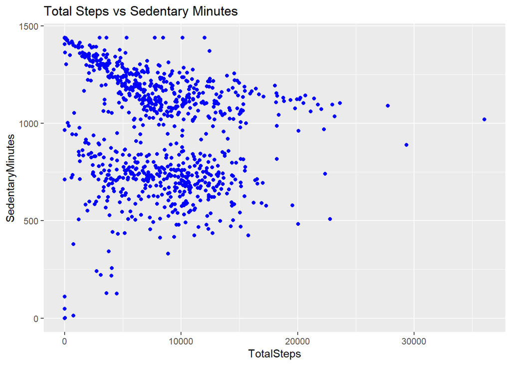

```r
ggplot(data=activity, aes(x=TotalSteps, y=SedentaryMinutes)) + geom_point(color='blue') + labs(title = "Total Steps vs Sedentary Minutes")
```

Looking at the relationship between Total Steps and Sedentary Minutes, there seems to be a negative correlation.

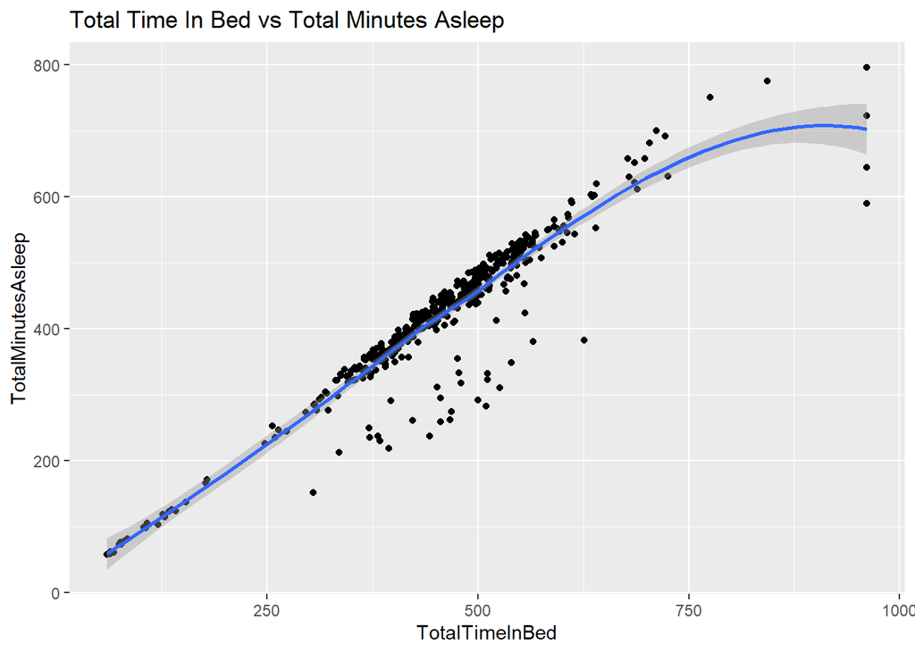

```r
ggplot(data=sleep, aes(x=TotalTimeInBed, y=TotalMinutesAsleep)) + geom_point() + geom_smooth() + labs(title = "Total Time In Bed vs Total Minutes Asleep")
```

Here, we can see that the relationship between Total Time in Bed and Total Minutes Asleep are practically linear considering a drop off in Total time in Bed.

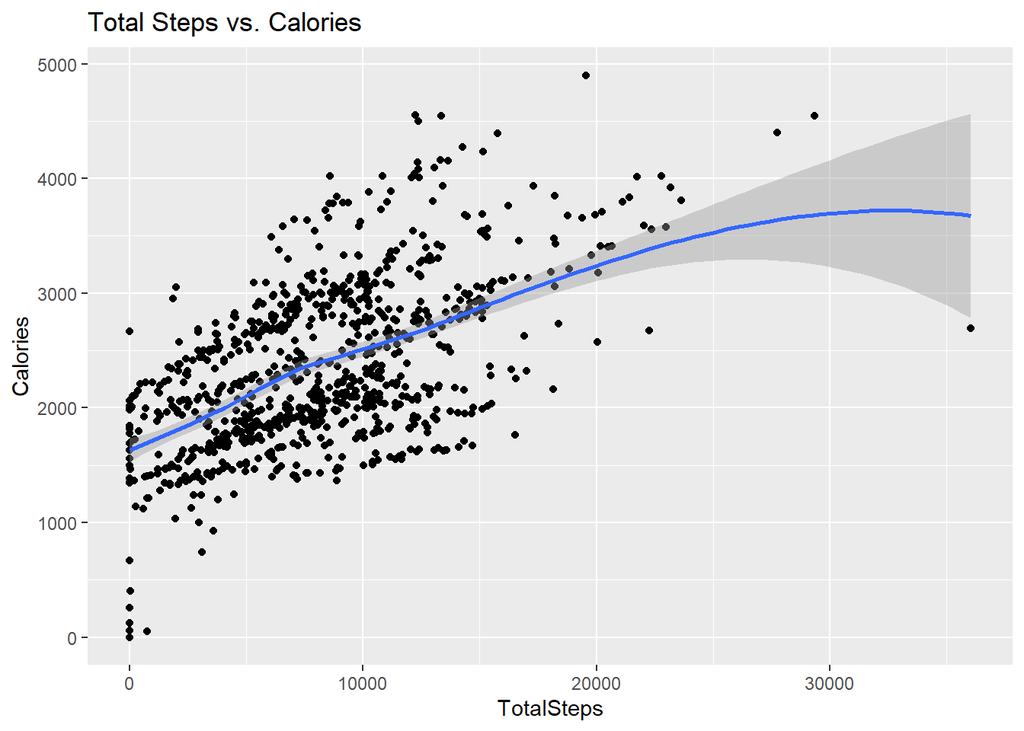

```r
ggplot(data=activity, aes(x=TotalSteps, y=Calories)) +
  geom_point() + geom_smooth() + labs(title="Total Steps vs. Calories")
```

Let’s take a glance at the Total Steps vs Calories visual. By observing the apparent information, we can see that there is a positive correlation between them, as the more steps you take, the more calories you burn.

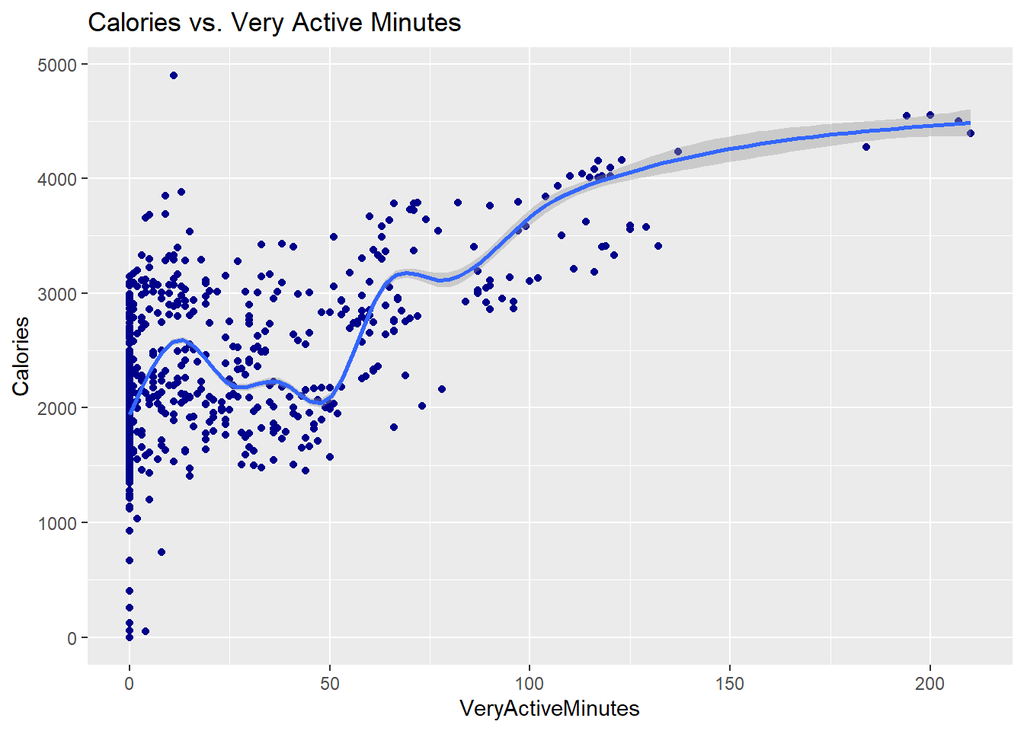

```r
ggplot(data=merged_data, aes(x=VeryActiveMinutes, y=Calories)) +
geom_point(color='darkblue') + geom_smooth() +
  labs(title="Calories vs. Very Active Minutes")
```

## Recommendations

As we reassess the information from the introduction, we know that the Bellabeat app provides users with health data related to their activity, sleep, stress, menstrual cycle, and mindfulness habits. This data can help users better understand their current habits and make healthy decisions.

##### **Key Ideas**

1. Bellabeat could include an app function to notify users of sedentary time periods. Letting a user know when to stand, stretch and/or take deep breaths could motivate a user to be more active.
2. Another key element could be a variety of different workouts. From walking, running and swimming to making their Leaf tracker water proof to appeal new customers and as a budding upgrade to previous users.
3. Since sleep quality factors in with health in general, Bellabeat could increase their potential by adding to the sleep feature by creating a schedule for the user that could stay consistent to the users sleep goals.
4. Lastly, constructing capabilities for all ages would be an efficient tool for marketing. Applying high and low heart rate notifications and fall detection would add an extra boost to the company in the global smart device market.

**ANY** recommendations to my Bellabeat Case Study using R would be greatly appreciated!